[figure not shown]

[OHI-Northeast](http://www.ohi-northeast.org/) | [OHI Science](http://ohi-science.org) | [Citation policy](http://ohi-science.org/citation-policy/)

# Creating the OHI Northeast regions

Compiled on Fri Jul 19 11:26:32 2019 by afflerbach

## Summary

- Northeast regional planning boundary
- US Exclusive Economic Zone
- Ecological Production Units
- State waters
- State land boundaries

The final regions file is called `ne_ohi_rgns` and found [here](https://github.com/OHI-Northeast/ne-prep/tree/gh-pages/spatial/shapefiles).

```r
knitr::opts_chunk$set(message = FALSE, warning = FALSE, root.dir = "ohi-northeast")

source('~/github/ne-prep/src/R/common.R') ### an OHI-NE specific version of common.R

dir_git <- '~/github/ohi-northeast'
dir_anx <- file.path(dir_M, 'git-annex/neprep')

library(tidyverse)
library(sf)
library(mapview)
library(mapedit)
```

## Ecological Production Units

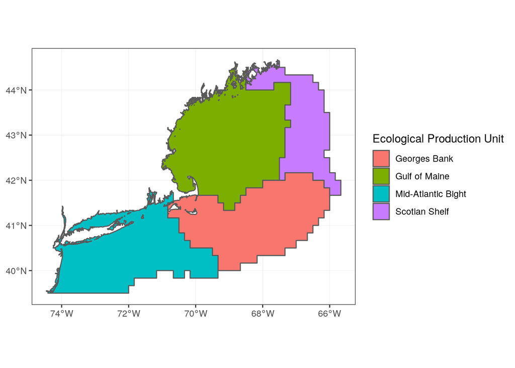

```r
epu <- st_read(file.path(dir_anx, 'spatial/data_for_rgn_options/Extended_EPU'), 'EPU_extended', quiet=T) %>%
         st_transform(p4s_nad83) %>%
         mutate(longname = c('Georges Bank','Gulf of Maine','Scotian Shelf','Mid-Atlantic Bight'))

#cropping epu extent for plotting
epu <- st_intersection(epu, st_set_crs(st_as_sf(as(raster::extent(-75,-65,39.5,45), "SpatialPolygons")), st_crs(epu)))

ggplot(epu) +
  geom_sf(aes(fill = longname)) +
  theme_bw() +
  labs(fill = "Ecological Production Unit")
```

The EPU’s don’t encompass all of Maine’s waters up to the border with Canada. I’m using the EEZ to extend the Northernmost EPU to Canada.

## US EEZ

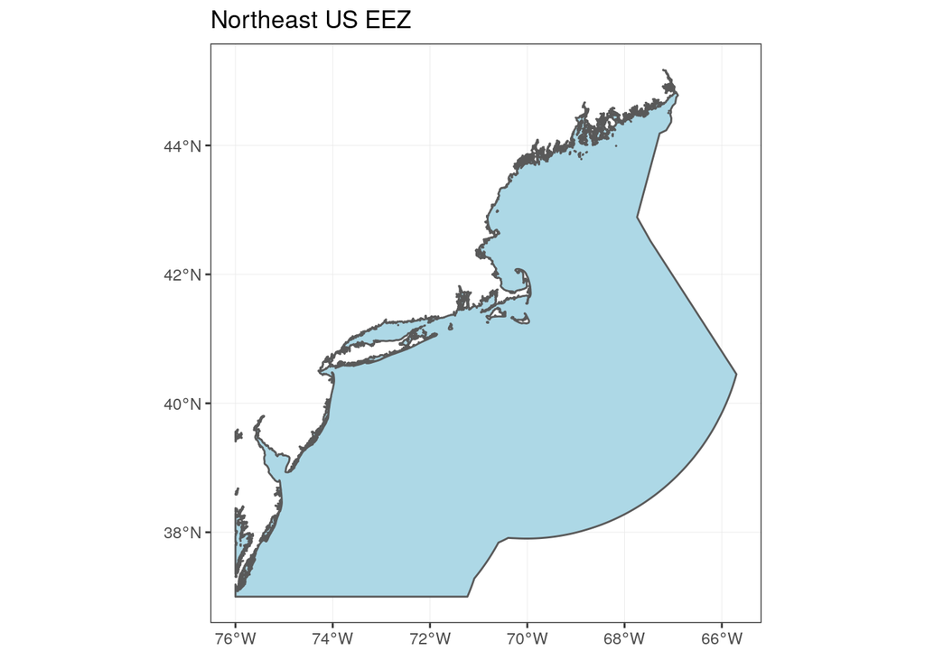

```r
eez <- st_read(dsn = 'shapefiles',layer = 'ne_eez',quiet=T)%>%
        st_transform(crs = p4s_nad83)

ggplot(eez) +
  geom_sf(fill = "lightblue") +
  labs(title = "Northeast US EEZ") +
  theme_bw()
```

We need to use the US EEZ to grab the tip of offshore Maine which will be added to the Scotian Shelf (and then Gulf of Maine EPU later in this script).

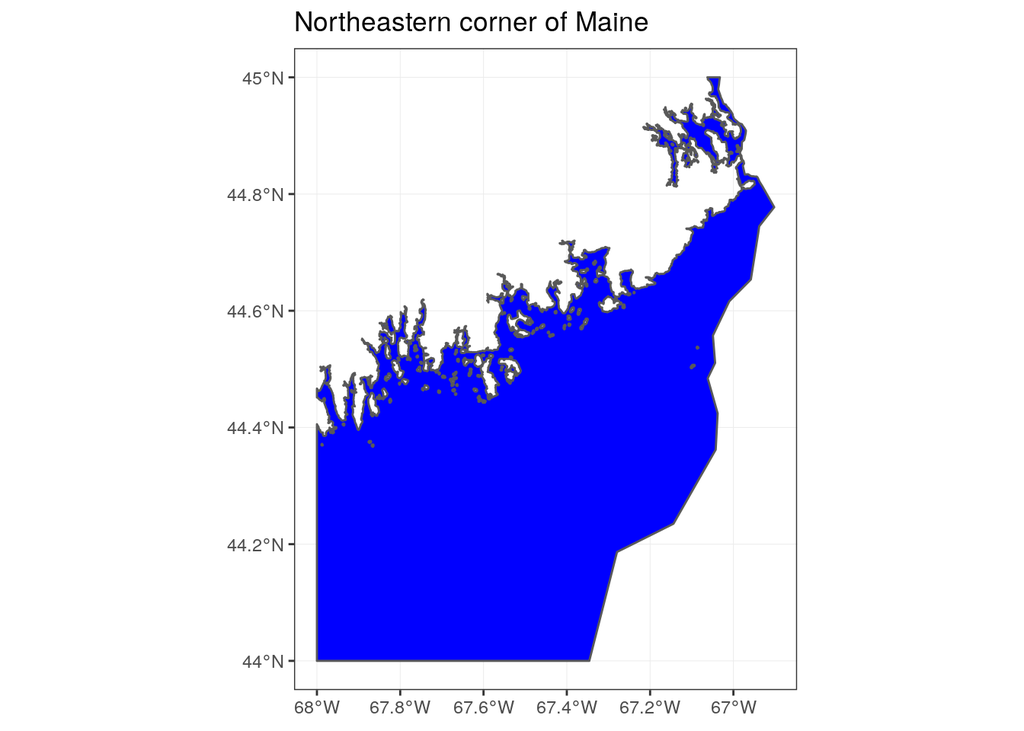

```r
maine <- st_intersection(eez, st_set_crs(st_as_sf(as(raster::extent(-68,-66,44,45), "SpatialPolygons")), st_crs(eez)))

ggplot(maine) +
  geom_sf(fill = "blue") +
  theme_bw() +
  labs(title = "Northeastern corner of Maine")
```

Now we can join the offshore region of Maine to the Scotian Shelf epu.

```r
ss <- epu%>%
         filter(longname == "Scotian Shelf") %>%
         st_union(maine) %>%
         dplyr::select(EPU, Shape_Leng, Shape_Area, longname, geometry) %>%
         st_cast("MULTIPOLYGON")

#join back to EPU

epu_ext <- epu %>%
            filter(EPU != "SS") %>%
             rbind(ss) %>%
             st_cast("MULTIPOLYGON")

st_write(epu_ext, "shapefiles/epu_extended.shp", driver = "ESRI Shapefile", delete_layer = T)
```

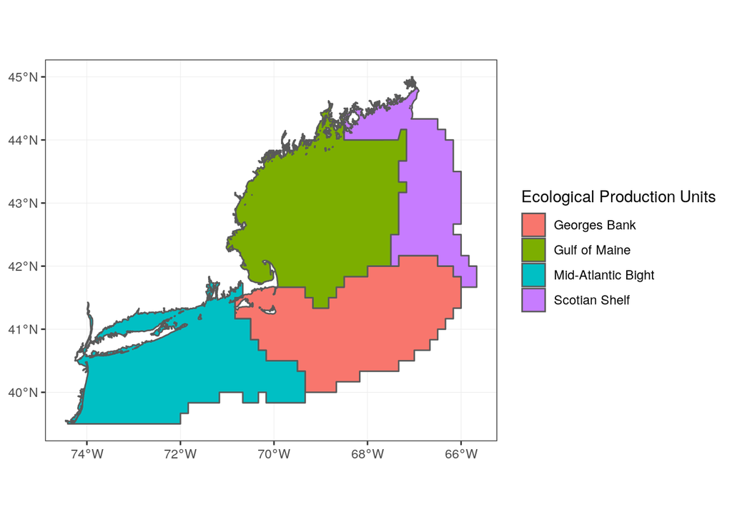

```r
epu_ext <- st_read('shapefiles', 'epu_extended', quiet=T)

ggplot(epu_ext) +
  geom_sf(aes(fill = longname)) +
  theme_bw() +
  labs(fill = "Ecological Production Units")
```

These look good. The next step is to intersect EPU’s with the Northeast ocean planning boundary so that we only have regions within the plan boundary.

## Northeast ocean planning boundary

```r
#ne study area plus state waters. I had to use this neoceanplanningboundary_polygon shapefile due to weird slivers when mergine the ne_plan_poly with state_wa

ne <- st_read(dsn = file.path(dir_anx, 'spatial'), layer = 'neoceanplanningboundary_polygon', quiet=T) %>%
        st_transform(crs = p4s_nad83) %>%
        group_by(Id) %>%
        summarize() %>%
        st_intersection(., eez)

st_write(ne, dsn = "shapefiles/ne_region_plus_states.shp", driver = "ESRI Shapefile", delete_layer = T)
```

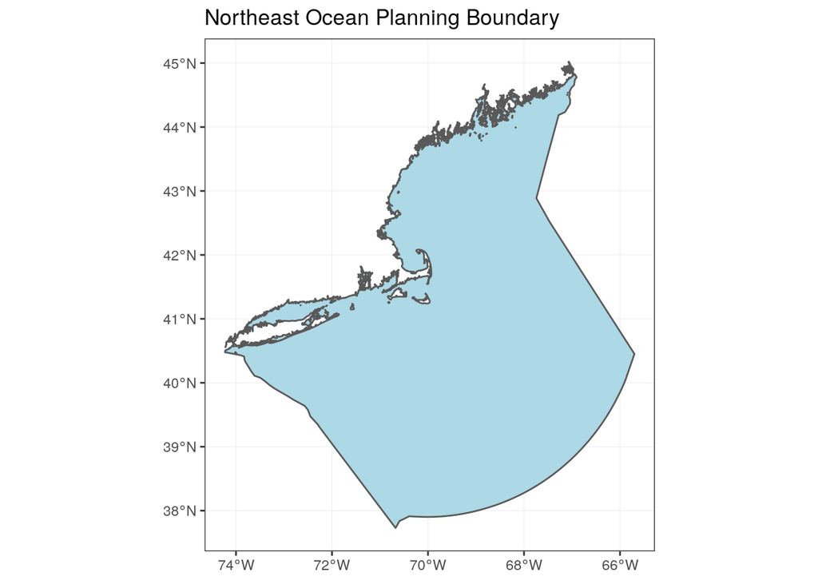

```r
ne_sa <- st_read(dsn = "shapefiles", layer = "ne_region_plus_states", quiet = T)

ggplot(ne_sa) +
  geom_sf(fill = "lightblue") +
  theme_bw() +
  labs(title = "Northeast Ocean Planning Boundary")
```

Intersect EPU with planning boundary

```r
#epus in the plan boundary (pb)

st_is_valid(epu_ext, reason = T)
epu_ext <- st_buffer(epu_ext, 0)

st_is_valid(epu_ext)

epu_pb <- st_intersection(epu_ext, ne_sa) %>%
  select(EPU, longname, geometry)
```

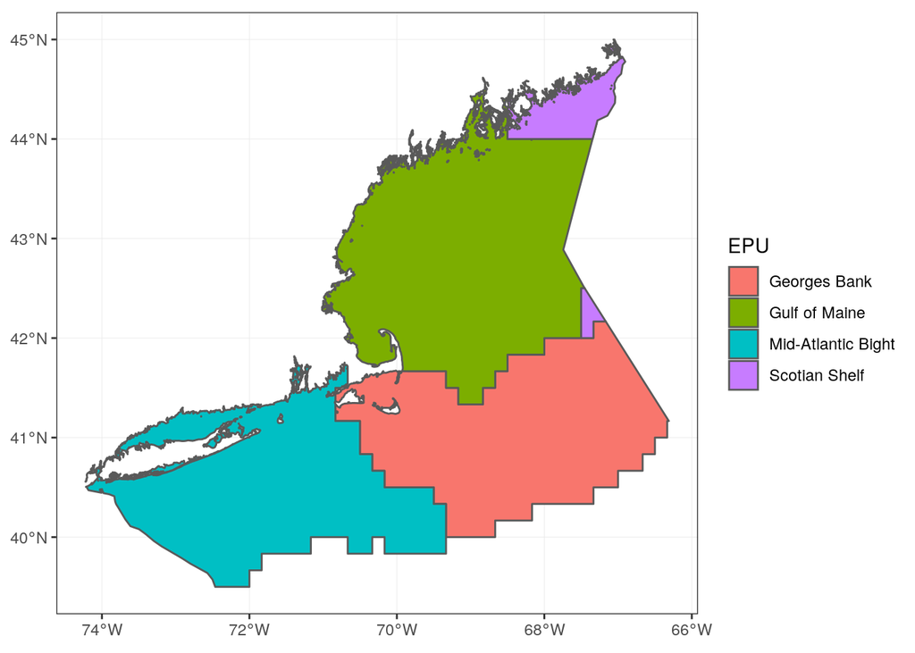

```r
ggplot(epu_pb) +
  geom_sf(aes(fill = longname)) +
  theme_bw() +
  labs(fill = "EPU")
```

Now I need to absorb the two scotian shelf pieces into gulf of maine

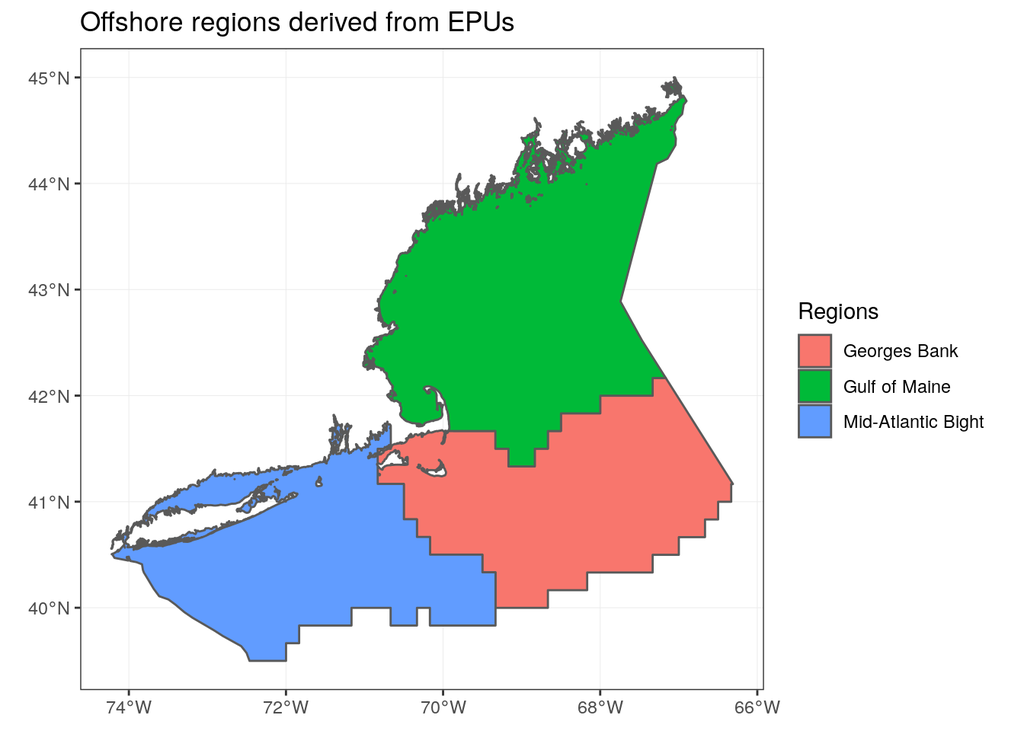

```r
epu_fix <- epu_pb %>%
  mutate(name = ifelse(EPU == "SS", "GOM", as.character(EPU)),
         longname = ifelse(EPU == "SS", "Gulf of Maine", as.character(longname))) %>%
  group_by(name, longname) %>%
  summarise(do_union=T) %>%
  st_buffer(0.001)

ggplot(epu_fix) +
  geom_sf(aes(fill = longname)) +
  theme_bw() +
  labs(fill = "Regions",
       title = "Offshore regions derived from EPUs")
```

We also want the region between the EPU’s and the southeastern boundary of the NE planning area to be the last offshore region.

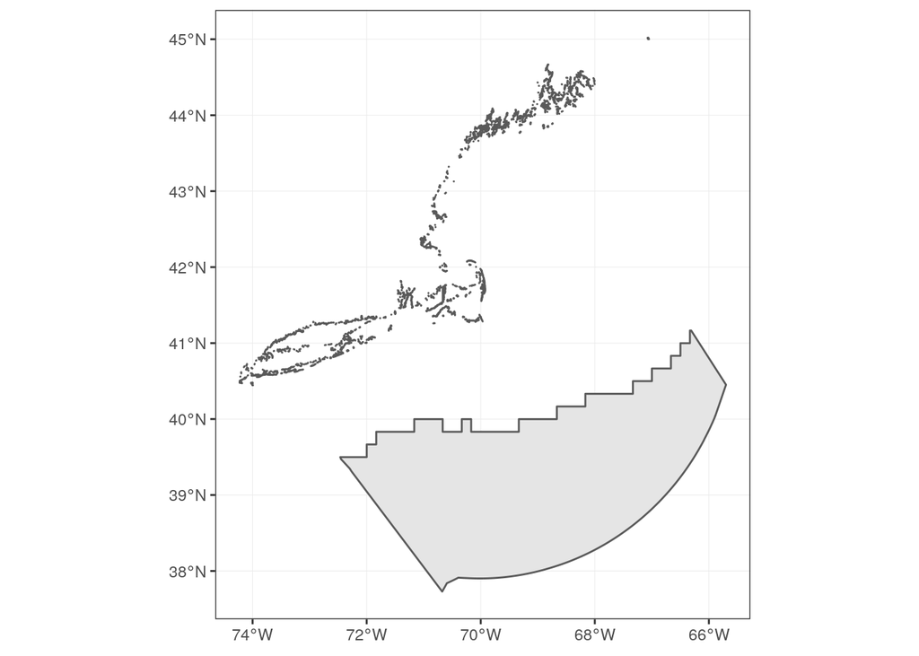

```r
epu_c <- st_union(epu_fix)

offshore <- st_difference(ne_sa, epu_c)

ggplot(offshore) +
  geom_sf() +
  theme_bw()
```

For some reason a lot of the coastline is still there. I split the offshore region simple feature into individual polygons, assign ID’s and then select just the offshore polygon which will remove the inland ones

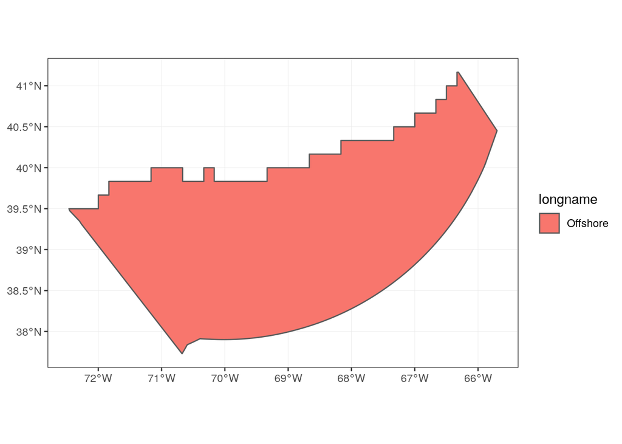

```r
offshore_rgn <- st_cast(offshore, "POLYGON") %>%
  mutate(id = 1:nrow(.)) %>%
  filter(id == 1) %>% #keep what we want
  mutate(name = "OS",
         longname = "Offshore") %>%
  select(name, longname, geometry)

ggplot(offshore_rgn) +
  geom_sf(aes(fill = longname)) +
  theme_bw()
```

I’m going to join this back to `epu_fix` and then remove state waters

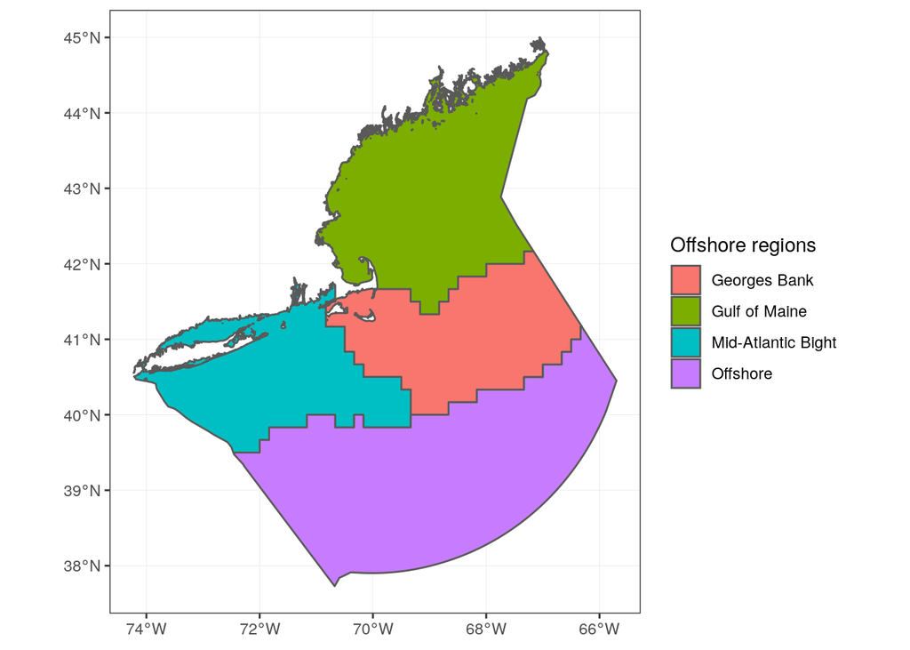

```r
epus <- epu_fix %>%
  rbind(offshore_rgn)

ggplot(epus) +
  geom_sf(aes(fill = longname)) +
  theme_bw() +
  labs(fill = "Offshore regions")
```

Load states + state waters shapefile from northeast ocean data portal. We use this instead of the state waters to remove state waters from EPU’s because it won’t leave any coastline in case there is mismatching between EPUs and state water shapefiles.

```r
states_plus_state_waters <- read_sf(file.path(dir_anx, "_raw_data/NEOceanDataPortal/Administrative/AdministrativeBoundaries.gdb"), layer = "States") %>%
  st_transform(crs = crs(epus))
```

Remove state waters from the EPUs since we just want these to be offshore regions.

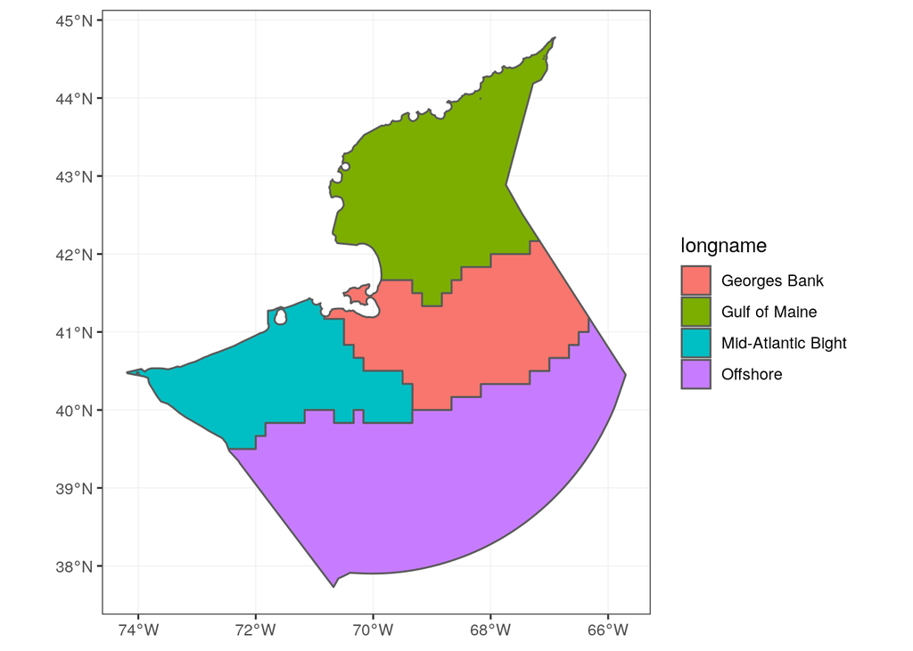

```r
## mask out state waters.
s = as(states_plus_state_waters, 'Spatial') #turning state_wa into a spatialpolygonsdataframe

epu_ext_offshore = as(epus, 'Spatial') - s

#transform back to simple feature

epu_ext_offshore <- st_as_sf(epu_ext_offshore) %>%
  st_cast(., "POLYGON") %>%
  mutate(id = 1:nrow(.))  %>%
  filter(id %in% c(14, 11, 1, 2)) #keep what we want

ggplot(epu_ext_offshore) +
  geom_sf(aes(fill = longname))  +
  theme_bw()
```

```r
##try to fix the small overlaps in polygons, mainly the issue is with George's Bank
clean_epu <- st_intersection(epu_ext_offshore) %>%
  mutate(id = 1:nrow(.)) %>%
  filter(id %in% c(5, 3, 4, 7, 1, 8)) %>% #keeping all the George's bank ones, and then only the other regions that have n.overlaps = 1
  group_by(name, longname) %>%
  summarize() %>%
  ungroup()
```

## State waters

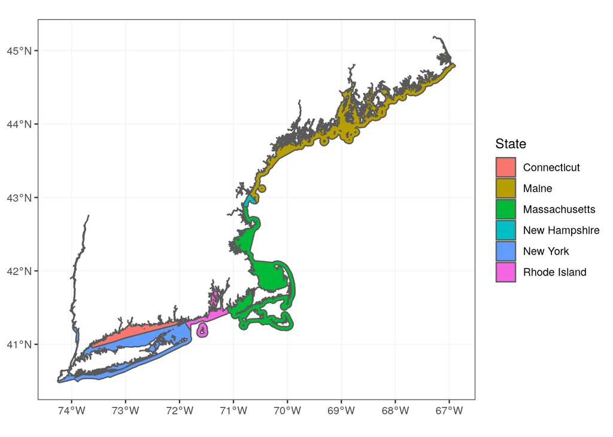

```r
state_wa <- st_read(dsn = file.path(dir_anx, 'spatial'), layer = 'StateWaters_wo_rivs_cleaned',quiet=T) %>%
              st_transform(p4s_nad83)

ggplot(state_wa) +
  geom_sf(aes(fill = NAME10)) +
  theme_bw() +
  labs(fill = "State")
```

Trying to erase the hudson river

```r
states <- st_read(dsn = 'shapefiles',layer = 'states',quiet=T)%>%
          st_transform(p4s_nad83) %>%
  filter(!NAME %in% c("Pennsylvania","New Jersey"))

ny <- states %>%
  filter(STUSPS == "NY")

#crop NY

ny_crop <- st_crop(ny, xmin = -81, xmax = -73, ymin = 41, ymax = 46)

#erase hudson river from state_Wa
st_erase = function(x, y) st_difference(x, st_union(st_combine(y)))

state_wa <- st_erase(state_wa, ny_crop)

write_sf(state_wa, "shapefiles/state_waters.shp")
```

Now we need to split Massachusetts waters into two regions using the EPUs as our separation line.

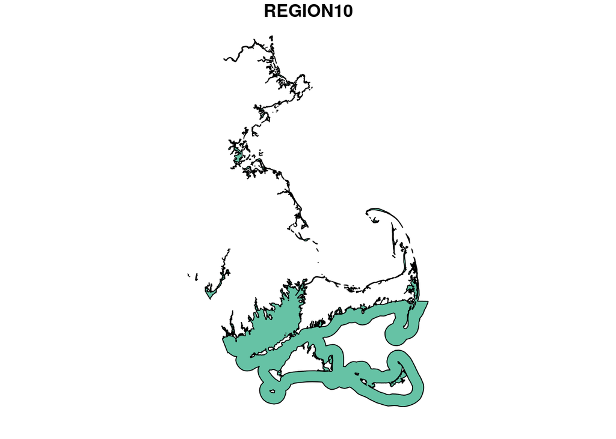

```r
#get Gulf of Maine EPU and use this to remove the northern part of MA

ma <- state_wa %>%
  filter(STUSPS10 == "MA")

ma_region_2 <- st_difference(ma, epus %>% filter(name == "GOM"))

plot(ma_region_2[1])
```

There is still a lot of excess coastal pieces. I think the best way to remove these is to use a hand drawn polygon mask

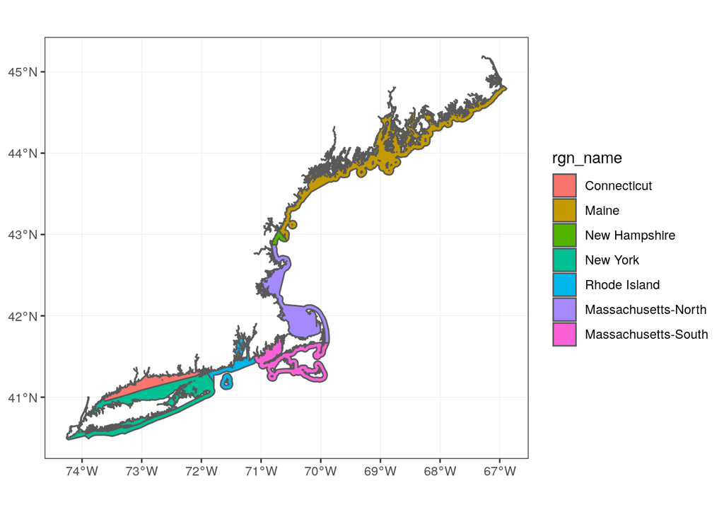

```r
 # north_ma_mask <- mapview(ma_region_2) %>%
 #   editMap()

#write_sf(north_ma_mask$finished, "shapefiles/north_ma_mask_poly.shp")

north_ma_mask <- read_sf("shapefiles/north_ma_mask_poly.shp") %>%
  st_transform(crs(ma))

ma_region_south <- st_difference(ma_region_2, north_ma_mask) %>%
  select(STUSPS10, NAME10) %>%
  mutate(rgn_name = "Massachusetts-South")
ma_region_north <- st_difference(ma, ma_region_south) %>%
  select(STUSPS10, NAME10) %>%
  mutate(rgn_name = "Massachusetts-North")

## combine Masachusetts back with the other states

state_rgns <- state_wa %>%
  filter(STUSPS10 != "MA") %>%
  select(STUSPS10, NAME10) %>%
  mutate(rgn_name = NAME10) %>%
  rbind(ma_region_north) %>%
  rbind(ma_region_south) %>%
  rename(state_abv = STUSPS10,
         state_name = NAME10)

ggplot(state_rgns)+
  geom_sf(aes(fill = rgn_name)) +
  theme_bw()
```

## Final regions

Now we combine state regions with offshore

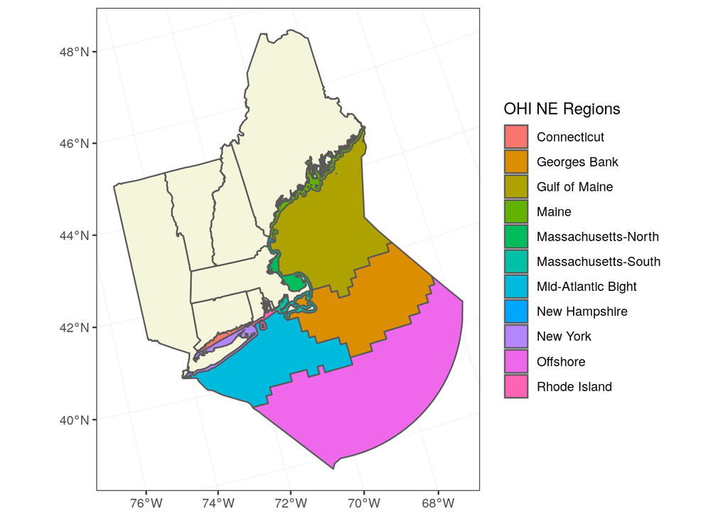

```r
#set US Albers equal area CRS - this is what we will use for all spatial data.
us_alb    <- "+proj=aea +lat_1=29.5 +lat_2=45.5 +lat_0=37.5 +lon_0=-96 +x_0=0 +y_0=0 +ellps=GRS80 +datum=NAD83 +units=m +no_defs"

ne_ohi_rgns <- clean_epu %>%
  rename(rgn_name = longname) %>%
  select(-name) %>%
  mutate(state_abv = NA,
         state_name = NA) %>%
  rbind(state_rgns) %>%
  mutate(rgn_id = case_when(
    rgn_name == "Offshore" ~ 1,
    rgn_name == "Georges Bank" ~ 2,
    rgn_name == "Gulf of Maine" ~ 3,
    rgn_name == "Mid-Atlantic Bight" ~ 4,
    rgn_name == "Connecticut" ~ 5,
    rgn_name == "Maine" ~ 6,
    rgn_name == "Massachusetts-North" ~ 7,
    rgn_name == "Massachusetts-South" ~ 8,
    rgn_name == "New Hampshire" ~ 9,
    rgn_name == "New York" ~ 10,
    rgn_name == "Rhode Island" ~ 11
  )) %>%
  arrange(rgn_id) %>%
  st_transform(crs = us_alb) %>%
  mutate(area_m2 = st_area(.),
         area_km2 = area_m2/1000000) %>%
  separate(area_km2, into = c("area_km2", "units"), sep = " ") %>%
  select(-area_m2, -units)


ggplot(ne_ohi_rgns) +
  geom_sf(aes(fill = rgn_name)) +
  geom_sf(data = states, fill = "beige") +
  theme_bw() +
  labs(fill = "OHI NE Regions")
```

# Make sure it is valid

```r
st_is_valid(ne_ohi_rgns)
```

```
##  [1]  TRUE FALSE  TRUE FALSE  TRUE  TRUE  TRUE  TRUE  TRUE  TRUE  TRUE
```

```r
#fix using lwgeom

ne_ohi_rgns <- lwgeom::st_make_valid(ne_ohi_rgns)
```

# Save

```r
st_write(ne_ohi_rgns, "shapefiles/ne_ohi_rgns.shp", delete_layer = T)
```

```
## Deleting layer `ne_ohi_rgns' using driver `ESRI Shapefile'
## Writing layer `ne_ohi_rgns' to data source `shapefiles/ne_ohi_rgns.shp' using driver `ESRI Shapefile'
## features:       11
## fields:         5
## geometry type:  Unknown (any)
```